## **Reading in the data:**

```r
ejscreen <- read.delim("../data/EJSCREEN_2020_IL.csv", sep = ",", header  = TRUE)
```

## **Investigating the variables**

First, I looked at the data using as_tibble to see more detail on the variables and make them more print friendly.

```r
ejscreen.tidy <- as_tibble(ejscreen)
```

## **Renaming the New Tibble**

Combining the steps to cleaning the variables above, I ran all of these commands together into a new tibble named “ejscreen.clean” containing only the 6 variables I’m working with.

```r
options(scipen = 999)
(ejscreen.clean <- ejscreen.tidy %>%
   rename(superfund.area = PNPL,
          rmp.area = PRMP,
          tsdf.area = PTSDF,
          census.region = ID,
          population = ACSTOTPOP,
          dem.index = VULEOPCT) %>%
   select(superfund.area, rmp.area, tsdf.area,  census.region, population, dem.index))
```

```
## # A tibble: 9,691 x 6
##    superfund.area rmp.area tsdf.area census.region population dem.index
##             <dbl>    <dbl>     <dbl>         <dbl>      <int>     <dbl>
##  1         0.0436    2.79      31.2   170313000000       1964     0.239
##  2         0.0306    1.28       8.24  170312000000        968     0.373
##  3         0.0384    1.88      28.5   170318000000       1371     0.272
##  4         0.0532    4.81       9.31  170313000000       2031     0.728
##  5         0.0305    2.63       7.90  170312000000        576     0.248
##  6         0.0431    2.91      40.4   170313000000       2446     0.491
##  7         0.0398    2.72      28.7   170312000000       1181     0.536
##  8         0.0326    0.872     12.8   170312000000       2223     0.530
##  9         0.0350    2.22      20.9   170318000000        620     0.161
## 10         0.0309    1.17       8.44  170312000000       1026     0.335
## # ... with 9,681 more rows
```

## **Descriptions of the variables**

The 6 variables I am analyzing are 3 environmental variables and 3 demographic variables.

The environmental variables are “superfund.area”, “rmp.area”, and “tsdf.area”.

- “superfund.area” indicates the count of proposed and listed “Superfund”, or National Priorities List, sites within 5 km, divided by distance in kilometers.
- “rmp.area” indicates the count of facilities that are RMP (Risk Management Plan) facilities within 5 km, divided by distance in kilometers
- “tsdf.area” indicates the count of facilities that are TSDF (Hazardous waste Treatment, Storage and Disposal Facilities) within 5 km, divided by distance in kilometers.

The demographic variables are “census.region”, “population”, and “dem.index”.

- “census.region” is the geographical census block being measured
- “population” is the count of persons living in the correlating census region
- “dem.index” represents a particular census region’s % minority population + % low-income population/2.

## **Using “is.na” and "complete.cases**

In order to check for missing variables, I use “is.na” and make sure that all values are “FALSE”. This omitted too many rows due to print max limitations, so I used “complete.cases” to return an affirmative answer that there were no missing variables.

```r
ejscreen.clean[!complete.cases(ejscreen.clean),]
```

```
## # A tibble: 0 x 6
## # ... with 6 variables: superfund.area <dbl>, rmp.area <dbl>, tsdf.area <dbl>,
## #   census.region <dbl>, population <int>, dem.index <dbl>
```

## **Preliminary Data Graphing**

By rendering a basic scatterplot, I can see that the data will require me to change some of these variables to categorical data so that I can analyze it more effectively.

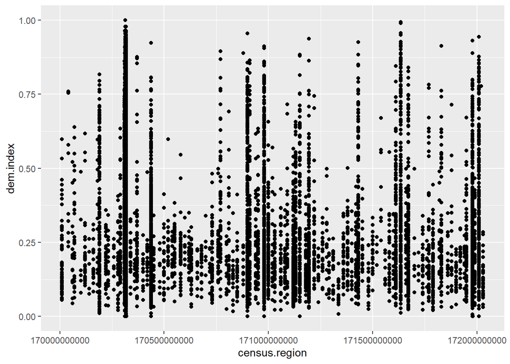

```r
ggplot(data = ejscreen.clean) +
  geom_point(mapping = aes(x = census.region, y = dem.index))
```

## **Summarizing Variables**

- I summarized and found the mean of the environmental variables- The mean value for superfund.area is 0.09851763, for rmp.area is 1.196261, and for tsdf.area is 4.087846, which helps me to determine where the values begin to indicate levels of risk that are higher or lower than the mean.
- I then summarized and found the mean of the demographic variable “dem.index”. The mean value for this variable is 0.3469023, which helps me to determine where the values begin to indicate levels of higher-risk populations within census regions.

```r
summarize(ejscreen.clean, tsdf.mean = mean(`tsdf.area`, na.rm = TRUE))
```

```
## # A tibble: 1 x 1
##   tsdf.mean
##       <dbl>
## 1      4.09
```

```r
summarize(ejscreen.clean, rmp.mean = mean(`rmp.area`, na.rm = TRUE))
```

```
## # A tibble: 1 x 1
##   rmp.mean
##      <dbl>
## 1     1.20
```

```r
summarize(ejscreen.clean, superfund.mean = mean(`superfund.area`, na.rm = TRUE))
```

```
## # A tibble: 1 x 1
##   superfund.mean
##            <dbl>
## 1         0.0985
```

```r
summarize(ejscreen.clean, dem.index.mean = mean(`dem.index`, na.rm = TRUE))
```

```
## # A tibble: 1 x 1
##   dem.index.mean
##            <dbl>
## 1          0.347
```

## **Census Region Values**

I checked how many occurrences there are of the census region codes in this dataset, and can see that the values of the individual data blocks contained in a given census block could potentially be combined into fewer values, but at this point I’m not sure how to do that without interfering with the rest of the data for each observation.

```r
table(ejscreen.clean$census.region)
```

```
##
## 170010000000 170040000000 170060000000 170070000000 170100000000 170120000000
##           61            9           15           27            6           37
## 170140000000 170160000000 170180000000 170190000000 170220000000 170231000000
##            5           18           15          150           37           20
## 170260000000 170279000000 170290000000 170310000000 170311000000 170312000000
##           10           31           51          197          333          360
## 170313000000 170314000000 170315000000 170316000000 170317000000 170318000000
##          199          155          156          176          295         2119
## 170320000000 170339000000 170360000000 170370000000 170400000000 170420000000
##            3           20           11           60           15           19
## 170438000000 170451000000 170480000000 170500000000 170520000000 170540000000
##          617           20            8           25           23           16
## 170550000000 170580000000 170600000000 170620000000 170630000000 170660000000
##           41           43            7           17           34           10
```

[output cut: 24 more lines]

## **Reclassifying Variable Values**

I will mutate the values for variable dem.index to create a way to easily view patterns of environmental risks in susceptible areas as indicated by the demographic index value.

```r
(ejscreen.categorical <- ejscreen.clean %>%
   mutate(dem.index = case_when(
     dem.index < 0.347 ~ "below.mean",
     dem.index > 0.347 ~ "above.mean",
     dem.index == 0.347 ~ "at.mean"
   )))
```

```
## # A tibble: 9,691 x 6
##    superfund.area rmp.area tsdf.area census.region population dem.index
##             <dbl>    <dbl>     <dbl>         <dbl>      <int> <chr>
##  1         0.0436    2.79      31.2   170313000000       1964 below.mean
##  2         0.0306    1.28       8.24  170312000000        968 above.mean
##  3         0.0384    1.88      28.5   170318000000       1371 below.mean
##  4         0.0532    4.81       9.31  170313000000       2031 above.mean
##  5         0.0305    2.63       7.90  170312000000        576 below.mean
##  6         0.0431    2.91      40.4   170313000000       2446 above.mean
##  7         0.0398    2.72      28.7   170312000000       1181 above.mean
##  8         0.0326    0.872     12.8   170312000000       2223 above.mean
##  9         0.0350    2.22      20.9   170318000000        620 below.mean
## 10         0.0309    1.17       8.44  170312000000       1026 below.mean
## # ... with 9,681 more rows
```

## **New Data Graphing**

By rendering new plots with the new categorical traffic, I can begin to see patterns.

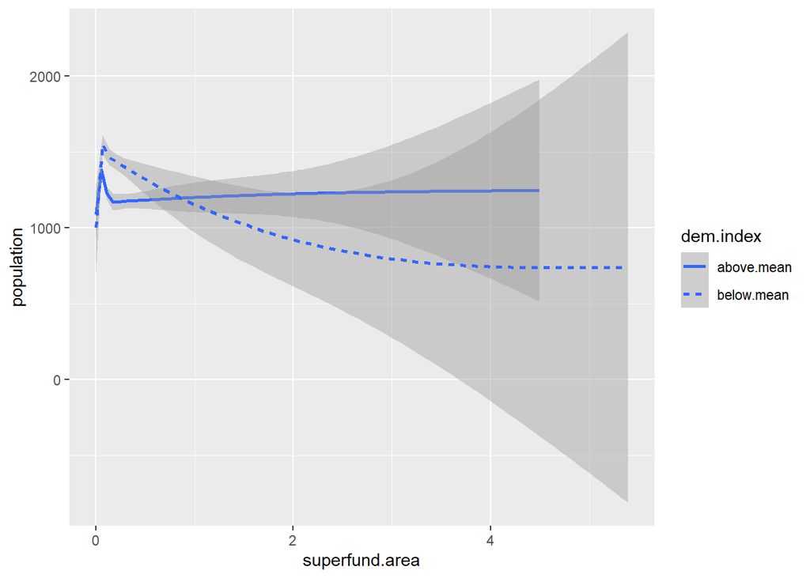

```r
ggplot(data = ejscreen.categorical) +
  geom_smooth(mapping = aes(x = superfund.area, y = population, linetype = dem.index))
```

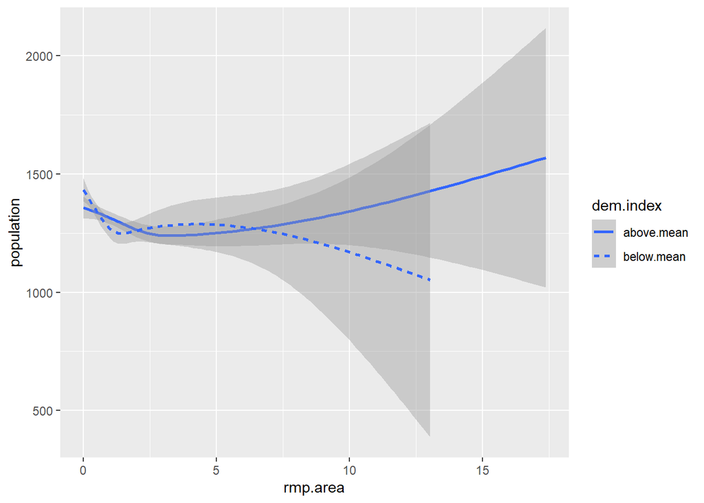

```r
ggplot(data = ejscreen.categorical) +
  geom_smooth(mapping = aes(x = rmp.area, y = population, linetype = dem.index))
```

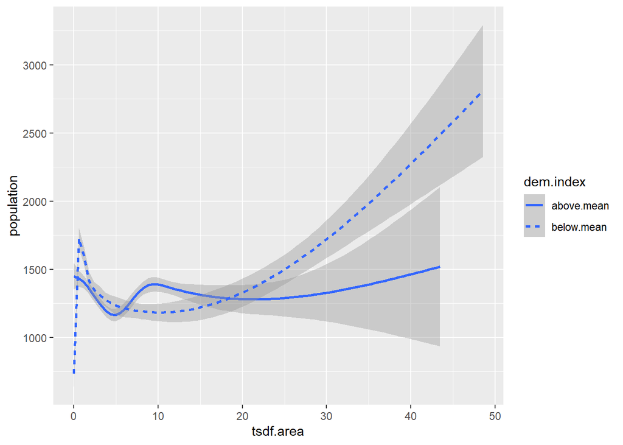

```r
ggplot(data = ejscreen.categorical) +
  geom_smooth(mapping = aes(x = tsdf.area, y = population, linetype = dem.index))
```

## **Reference**

United States Environmental Protection Agency (EPA), 2020 version, updated July 1, 2021. EJSCREEN. Retrieved: July 16, 2021 (https://gaftp.epa.gov/EJSCREEN/2020/)